# ProblemSet2

Mei Iwamoto

9/4/2024

```r
#Question 1
#k=100, r=1
N <- vector()
N[1] <- 2

for(t in 1:15){ N[t+1] <- N[t]+N[t]*(1-(N[t]/100))}
print(N)
```

```
##  [1]   2.000000   3.960000   7.763184  14.923698  27.620228  47.611686
##  [7]  72.554646  92.467525  99.432618  99.996781 100.000000 100.000000
## [13] 100.000000 100.000000 100.000000 100.000000
```

#Question 2

```r
C <- N[2:16]-N[1:15]
print(C)
```

```
##  [1] 1.960000e+00 3.803184e+00 7.160514e+00 1.269653e+01 1.999146e+01
##  [6] 2.494296e+01 1.991288e+01 6.965093e+00 5.641625e-01 3.219117e-03
## [11] 1.036338e-07 0.000000e+00 0.000000e+00 0.000000e+00 0.000000e+00
```

```r
#double check answer above
N[2]-N[1]
```

```
## [1] 1.96
```

#Question 3

```r
Npc <- C[1:15]/N[1:15]
print(Npc)
```

```
##  [1] 9.800000e-01 9.604000e-01 9.223682e-01 8.507630e-01 7.237977e-01
##  [6] 5.238831e-01 2.744535e-01 7.532475e-02 5.673818e-03 3.219221e-05
## [11] 1.036338e-09 0.000000e+00 0.000000e+00 0.000000e+00 0.000000e+00
```

```r
#check answer
(N[2]-N[1])/N[1]
```

```
## [1] 0.98
```

```r
(N[3]-N[2])/N[2]
```

```
## [1] 0.9604
```

#Question 4

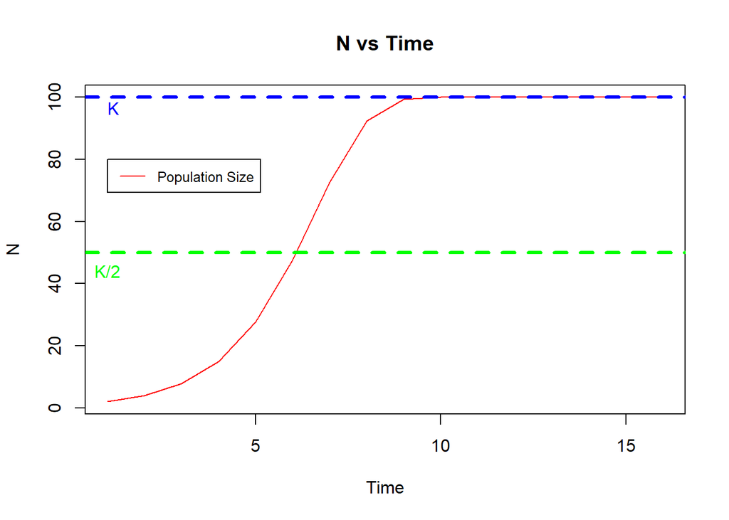

```r
#for plotting k/2, use ab line function, text function to label. abline(v=10,...)
#N vs time plot
plot(x= 1:16, y=N, xlab = 'Time', ylab='N', main='N vs Time', col=('red'), type = "l",)
legend(1,80, legend=c("Population Size"), col=c('red'), lty=1:2, cex=0.8)
abline(h=100, col="blue", lwd=3, lty=2)
text(1,94, "K", col = "blue", adj = c(0, -.1))
abline(h=50, col="green", lwd=3, lty=2)
text(1,44, "K/2", col='green')
```

#population growth rate vs. N

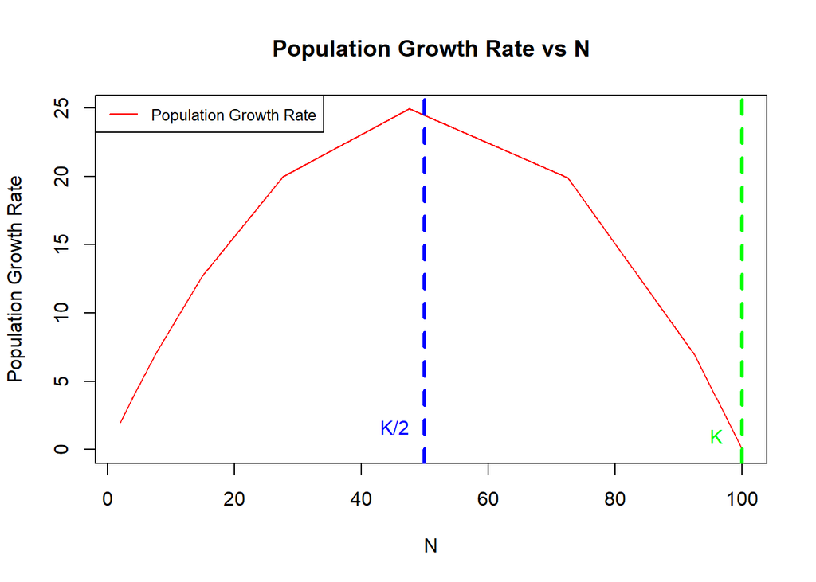

```r
plot(x=N[1:15], y=C, xlab = 'N', ylab='Population Growth Rate', main='Population Growth Rate vs N', col=('red'), type = "l")
legend('topleft', legend=c("Population Growth Rate"), col=c('red'), lty=1:2, cex=0.8)
abline(v=50, col="blue", lwd=3, lty=2)
text(43, 1, "K/2", col = "blue", adj = c(0, -.1))
abline(v=100, col="green", lwd=3, lty=2)
text(96,1, "K", col='green')
```

#per capita growth rate vs. N

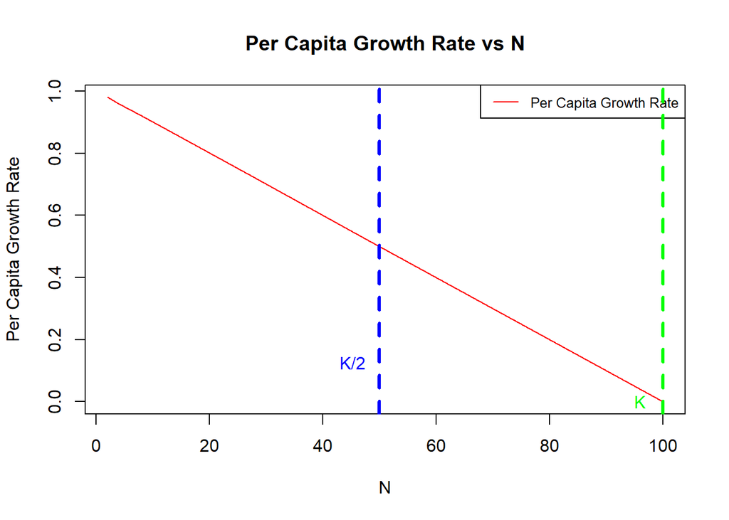

```r
plot(x=N[1:15], y=Npc, xlab = 'N', ylab='Per Capita Growth Rate', main='Per Capita Growth Rate vs N', col=('red'), type = "l")
legend('topright', legend=c("Per Capita Growth Rate"), col=c('red'), lty=1:2, cex=0.8)
abline(v=50, col="blue", lwd=3, lty=2)
text(43, 0.1, "K/2", col = "blue", adj = c(0, -.1))
abline(v=100, col="green", lwd=3, lty=2)
text(96,0, "K", col='green')
```

#Question 5: Per capita growth is the greatest when N is small because per capita growth is when you divide the population growth rate by the population size at that time. Whereas the population growth rate is greatest when K=2 because that’s when there is the greatest number of individuals in the population where resources are not yet limited.

#Question 6

```r
V <- vector()
V[1] <- 120
for(t in 1:15){ V[t+1] <- V[t]+V[t]*(1-(V[t]/100))}
print(V)
```

```
##  [1] 120.00000  96.00000  99.84000  99.99974 100.00000 100.00000 100.00000
##  [8] 100.00000 100.00000 100.00000 100.00000 100.00000 100.00000 100.00000
## [15] 100.00000 100.00000
```

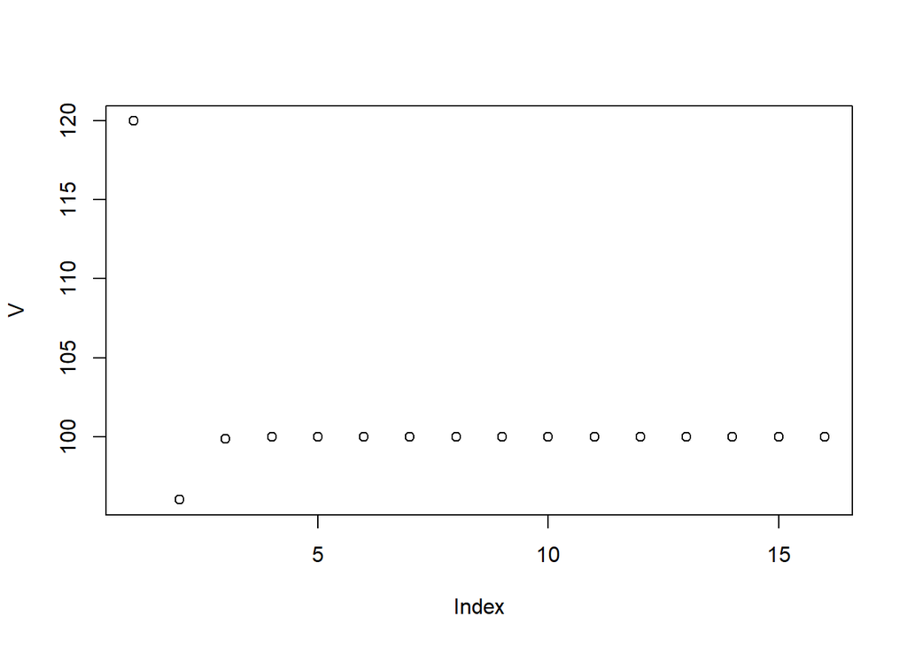

```r
plot(V)
```

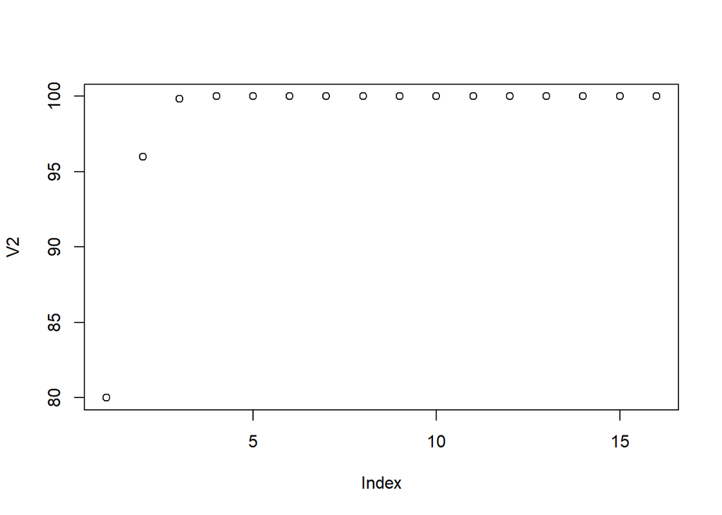

```r
V2 <- vector()
V2[1] <- 80
for(t in 1:15){ V2[t+1] <- V2[t]+V2[t]*(1-(V2[t]/100))}
plot(V2)
```

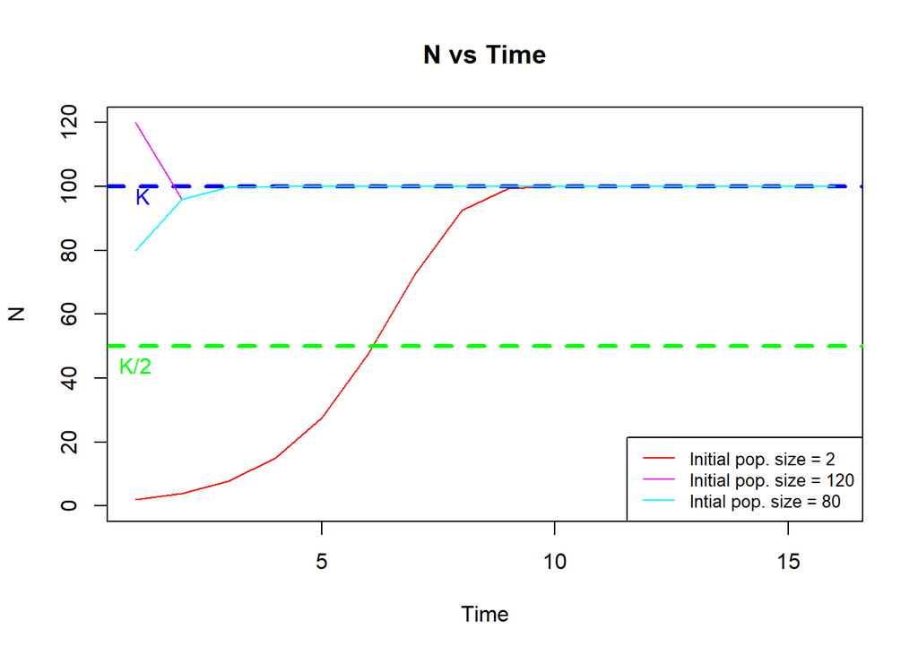

```r
#plot all on same plot
plot(x= 1:16, y=N, xlab = 'Time', ylab='N', main='N vs Time', col=('red'), type = "l",ylim=c(0,120))
legend("bottomright", legend=c("Initial pop. size = 2", "Initial pop. size = 120", "Intial pop. size = 80"), col=c('red', 'magenta', 'cyan'), lty=1, cex=0.8)
abline(h=100, col="blue", lwd=3, lty=2)
text(1,94, "K", col = "blue", adj = c(0, -.1))
abline(h=50, col="green", lwd=3, lty=2)
text(1,44, "K/2", col='green')
lines(x=1:16, y=V, col='magenta')
lines(x=1:16, y=V2, col='cyan')
```

#When starting out with an initial pop. size closer to K but still less than, it reaches K much faster. When starting out with an initial pop. size greater than K, the population drops below carrying capacity a bit before going back to K.

#Question 7, r: 1.3, 1.6, 1.9, 2.2, 2.5, 2.8

```r
#r=1.3
R1<- vector()
R1[1]=2
for(t in 1:15){ R1[t+1] <- R1[t]+R1[t]*1.3*(1-(R1[t]/100))}
print(R1)
```

```
##  [1]   2.00000   4.54800  10.19150  22.09019  44.46375  76.56529  99.89100
##  [8] 100.03255  99.99022 100.00293  99.99912 100.00026  99.99992 100.00002
## [15]  99.99999 100.00000
```

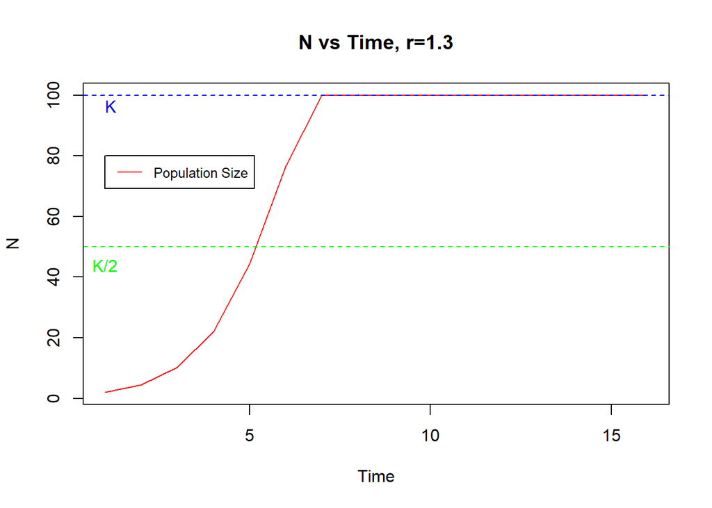

```r
plot(x= 1:16, y=R1, xlab = 'Time', ylab='N', main='N vs Time, r=1.3', col=('red'), type = "l",)
legend(1,80, legend=c("Population Size"), col=c('red'), lty=1:2, cex=0.8)
abline(h=100, col="blue", lwd=1, lty=2)
text(1,94, "K", col = "blue", adj = c(0, -.1))
abline(h=50, col="green", lwd=1, lty=2)
text(1,44, "K/2", col='green')
```

```r
#r=1.6
R2<- vector()
R2[1]=2
for(t in 1:15){ R2[t+1] <- R2[t]+R2[t]*1.6*(1-(R2[t]/100))}
print(R2)
```

```
##  [1]   2.00000   5.13600  12.93154  30.94642  65.13779 101.47135  99.08255
##  [8] 100.53700  99.67319 100.19438  99.88277 100.07012  99.95785 100.02526
## [15]  99.98483 100.00910
```

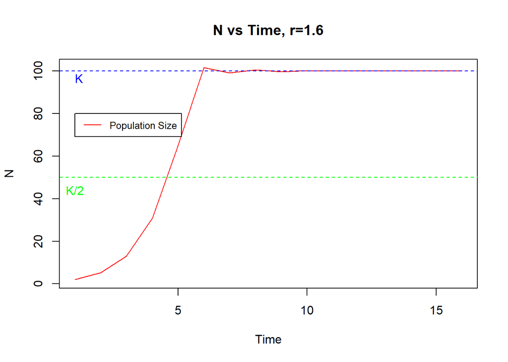

```r
plot(x= 1:16, y=R2, xlab = 'Time', ylab='N', main='N vs Time, r=1.6', col=('red'), type = "l",)
legend(1,80, legend=c("Population Size"), col=c('red'), lty=1:2, cex=0.8)
abline(h=100, col="blue", lwd=1, lty=2)
text(1,94, "K", col = "blue", adj = c(0, -.1))
abline(h=50, col="green", lwd=1, lty=2)
text(1,44, "K/2", col='green')
```

```r
#r=1.9
R3<-vector()
R3[1]<-2
for(t in 1:15){ R3[t+1] <- R3[t]+R3[t]*1.9*(1-(R3[t]/100))}
print(R3)
```

```
##  [1]   2.00000   5.72400  15.97708  41.48346  87.60536 108.23626  91.29848
##  [8] 106.39275  93.47004 105.06680  94.95211 104.05896  96.03391 103.27061
## [15]  96.85321 102.64397
```

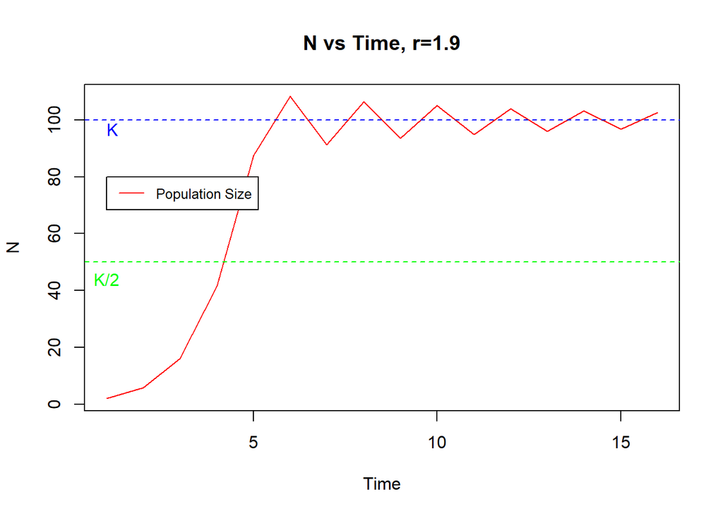

```r
plot(x= 1:16, y=R3, xlab = 'Time', ylab='N', main='N vs Time, r=1.9', col=('red'), type = "l",)
legend(1,80, legend=c("Population Size"), col=c('red'), lty=1:2, cex=0.8)
abline(h=100, col="blue", lwd=1, lty=2)
text(1,94, "K", col = "blue", adj = c(0, -.1))
abline(h=50, col="green", lwd=1, lty=2)
text(1,44, "K/2", col='green')
```

```r
#r=2.2
R4<-vector()
R4[1]<-2
for(t in 1:15){ R4[t+1] <- R4[t]+R4[t]*2.2*(1-(R4[t]/100))}
print(R4)
```

```
##  [1]   2.00000   6.31200  19.32189  53.61667 108.32890  88.47916 110.90495
##  [8]  84.29786 113.41831  79.93691 115.22010  76.63955 116.02691  75.11675
## [15] 116.23802  74.71355
```

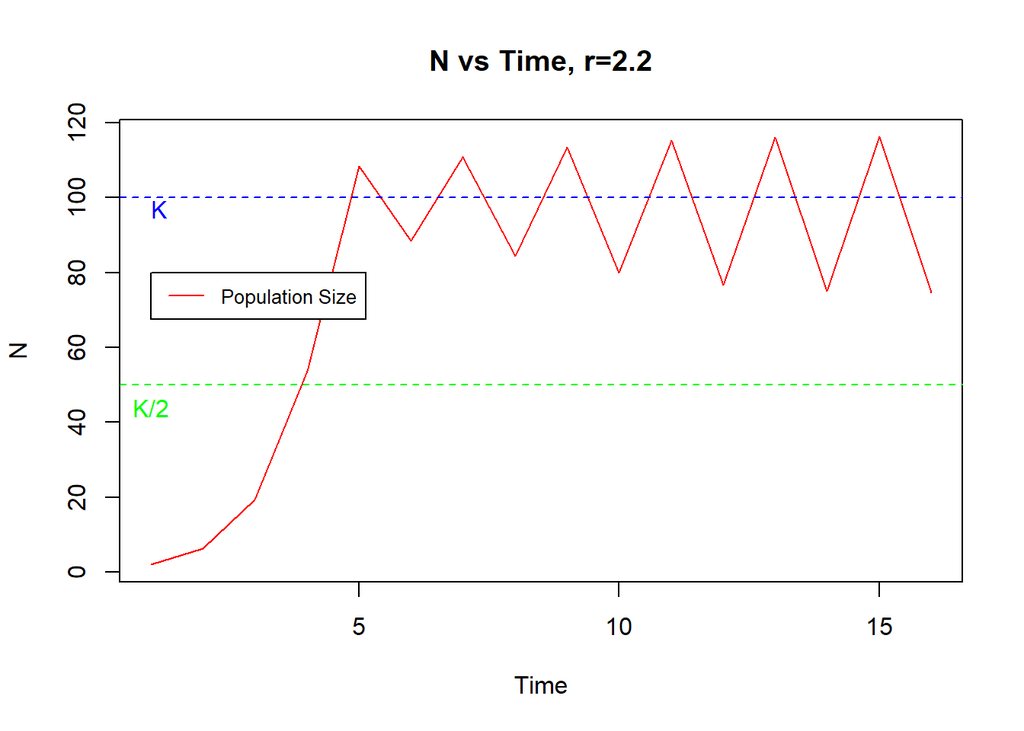

```r
plot(x= 1:16, y=R4, xlab = 'Time', ylab='N', main='N vs Time, r=2.2', col=('red'), type = "l",)
legend(1,80, legend=c("Population Size"), col=c('red'), lty=1:2, cex=0.8)
abline(h=100, col="blue", lwd=1, lty=2)
text(1,94, "K", col = "blue", adj = c(0, -.1))
abline(h=50, col="green", lwd=1, lty=2)
text(1,44, "K/2", col='green')
```

```r
#r=2.5
R5<-vector()
R5[1]<-2
for(t in 1:15){ R5[t+1] <- R5[t]+R5[t]*2.5*(1-(R5[t]/100))}
print(R5)
```

```
##  [1]   2.00000   6.90000  22.95975  67.18037 122.30124  54.11450 116.19127
##  [8]  69.15916 122.48232  53.64014 115.80887  70.03868 122.49996  53.59385
## [15] 115.77095  70.12549
```

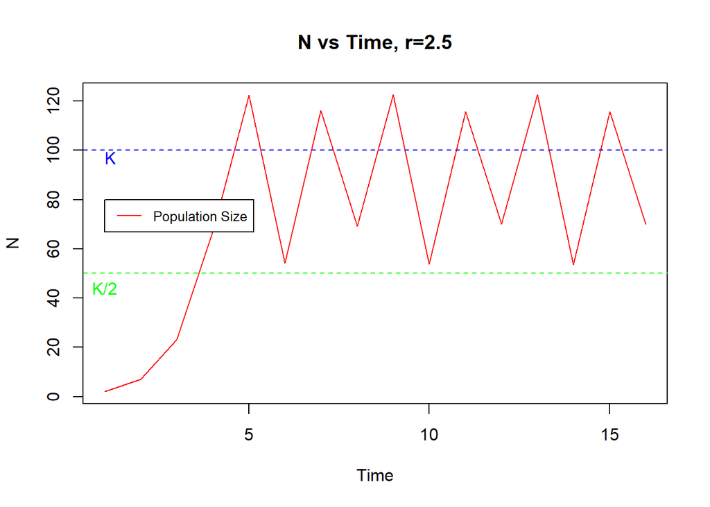

```r
plot(x= 1:16, y=R5, xlab = 'Time', ylab='N', main='N vs Time, r=2.5', col=('red'), type = "l",)
legend(1,80, legend=c("Population Size"), col=c('red'), lty=1:2, cex=0.8)
abline(h=100, col="blue", lwd=1, lty=2)
text(1,94, "K", col = "blue", adj = c(0, -.1))
abline(h=50, col="green", lwd=1, lty=2)
text(1,44, "K/2", col='green')
```

```r
#r=2.8
R6<-vector()
R6[1]<-2
for(t in 1:15){ R6[t+1] <- R6[t]+R6[t]*2.8*(1-(R6[t]/100))}
print(R6)
```

```
##  [1]   2.00000   7.48800  26.88444  81.92322 123.38865  42.58363 111.04355
##  [8]  76.70673 126.73575  31.86125  92.64885 111.71897  75.06049 127.47570
## [15]  29.40614  87.53113
```

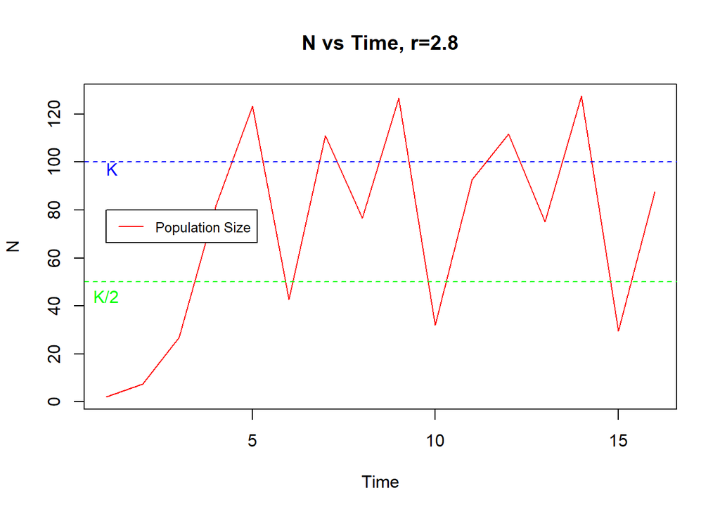

```r
plot(x= 1:16, y=R6, xlab = 'Time', ylab='N', main='N vs Time, r=2.8', col=('red'), type = "l",)
legend(1,80, legend=c("Population Size"), col=c('red'), lty=1:2, cex=0.8)
abline(h=100, col="blue", lwd=1, lty=2)
text(1,94, "K", col = "blue", adj = c(0, -.1))
abline(h=50, col="green", lwd=1, lty=2)
text(1,44, "K/2", col='green')
```

#Question 8

```r
R7<-vector()
R7[1]<-3
for(t in 1:15){ R7[t+1] <- R7[t]+R7[t]*2.8*(1-(R7[t]/100))}
print(R7)
```

```
##  [1]   3.00000  11.14800  38.88262 105.42193  89.41741 115.91291  64.26659
##  [8] 128.56759  25.72733  79.23077 125.30651  36.51655 101.42606  97.37615
## [15] 104.53016  91.27109
```

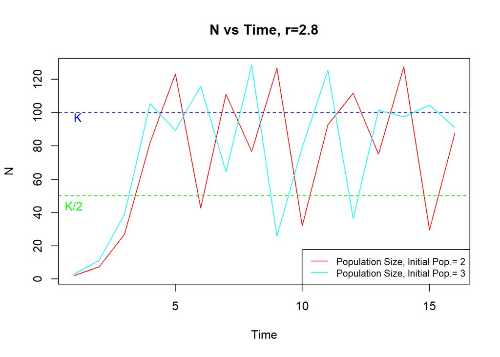

```r
#plot
plot(x= 1:16, y=R6, xlab = 'Time', ylab='N', main='N vs Time, r=2.8', col=('red'), type = "l",)
legend("bottomright", legend=c("Population Size, Initial Pop.= 2", "Population Size, Initial Pop.= 3"), col=c('red','cyan'), lty=1, cex=0.8)
abline(h=100, col="blue", lwd=1, lty=2)
text(1,94, "K", col = "blue", adj = c(0, -.1))
abline(h=50, col="green", lwd=1, lty=2)
text(1,44, "K/2", col='green')
lines(x=1:16, y=R7, col='cyan')
```

```r
#We can see that there is sensitivity to initial conditions here, where just changing the initial population by one causes the population sizes to be pretty different between the two plotted simulations here (although the behavior of the simulations are similar, they don't align completely).
```

#Question 9 #If chaos is common in nature, there may be implications to how well we can forecast population dynamics and there may be limits to it. In that case, it may be best to take into account the possibility of chaos whenever doing any such forecasts and keeping that in mind as any management actions are taken.